# Analisi infortunati in Friuli Venezia Giulia

Giacomo Colussi

# Uno sguardo sul lavoro

Sfruttando i dati INAIL incrociati con dati ISTAT cosa possiamo dire a rigurado della distribuzione degli infortuni in Friuli Venezia Giulia?

> Quali settori sono i più pericolosi?

> Come sono distribuiti gli infortuni tra le età e i sessi?

> Quali sono i mesi con più infortuni registrati?

# Settori dove avvengono più infortuni

Individuiamo quali sono i settori con più infortuni e stiliamo una classifica

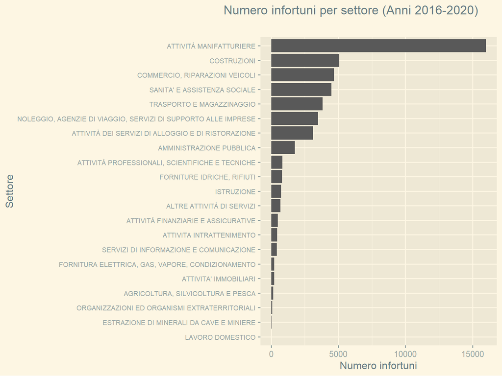

Vediamo come il settore manifatturiero è di gran lunga quello che registra più infortuni

Andiamo poi a incrociare il numero di infortuni con il numero di infortuni fatali per andare a cercare quali sono i settori più rischiosi

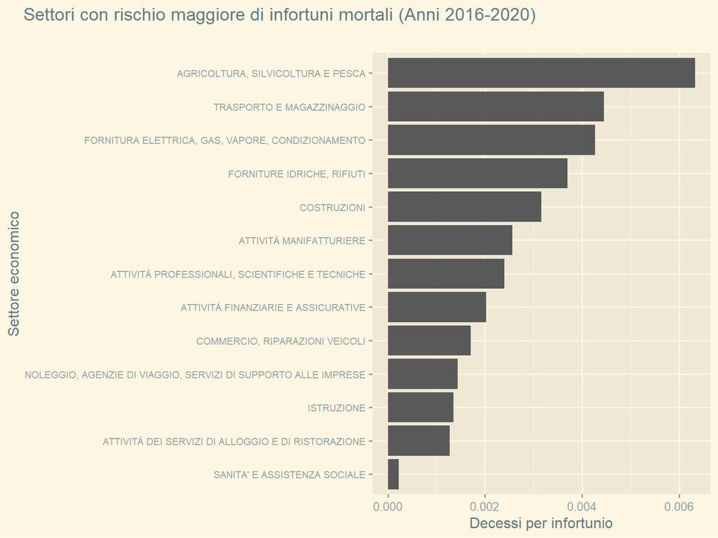

# Confronto tra gli infortuni maschili e femminili per età

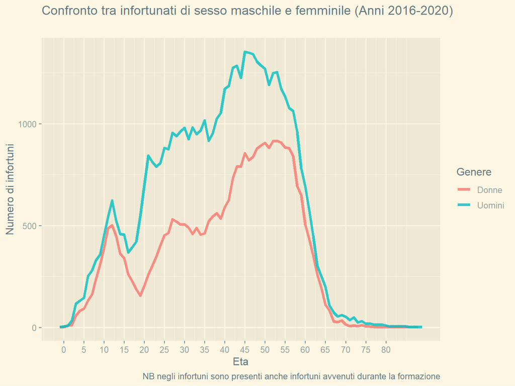

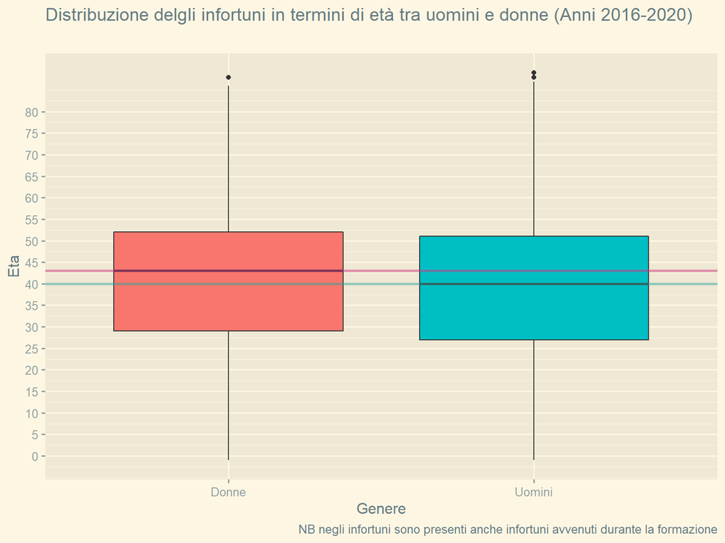

Come suggerito dal *line graph* vediamo che la distribuzione degli infortuni nelle donne è spostata verso età maggiori, supposizione confermataci dal *box plot*

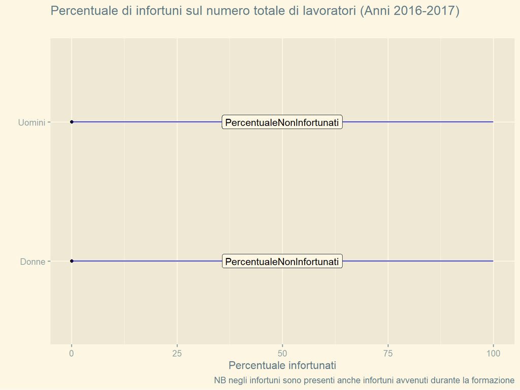

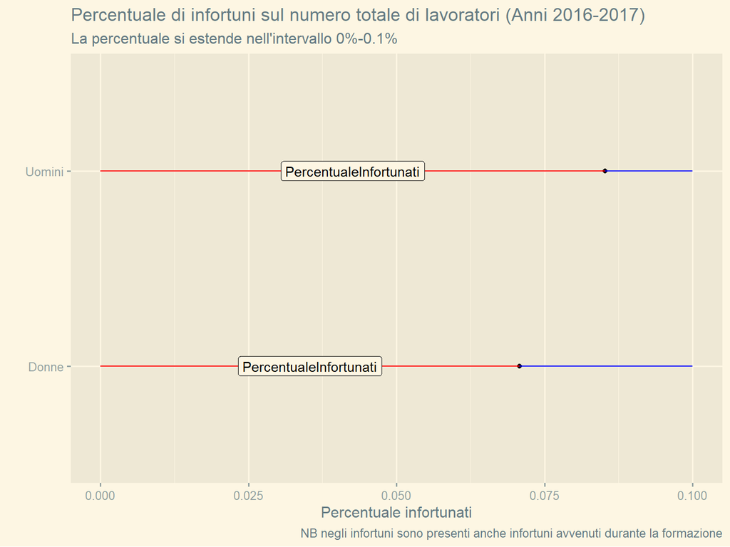

*Capo III - Persone assicurate […] 5) gli insegnanti e gli alunni delle scuole o istituti di istruzione di qualsiasi ordine e grado, anche privati, che attendano ad esperienze tecnico-scientifiche od esercitazioni pratiche, o che svolgano esercitazioni di lavoro; gli istruttori e gli allievi dei corsi di qualificazione o riqualificazione professionale o di addestramento professionale anche aziendali, o dei cantieri scuola, comunque istituiti o gestiti, nonché i preparatori, gli inservienti e gli addetti alle esperienze ed esercitazioni tecnico-pratiche o di lavoro;* D.P.R. 30 giugno 1965, n. 1124

# Infortuni suddivisi per mese

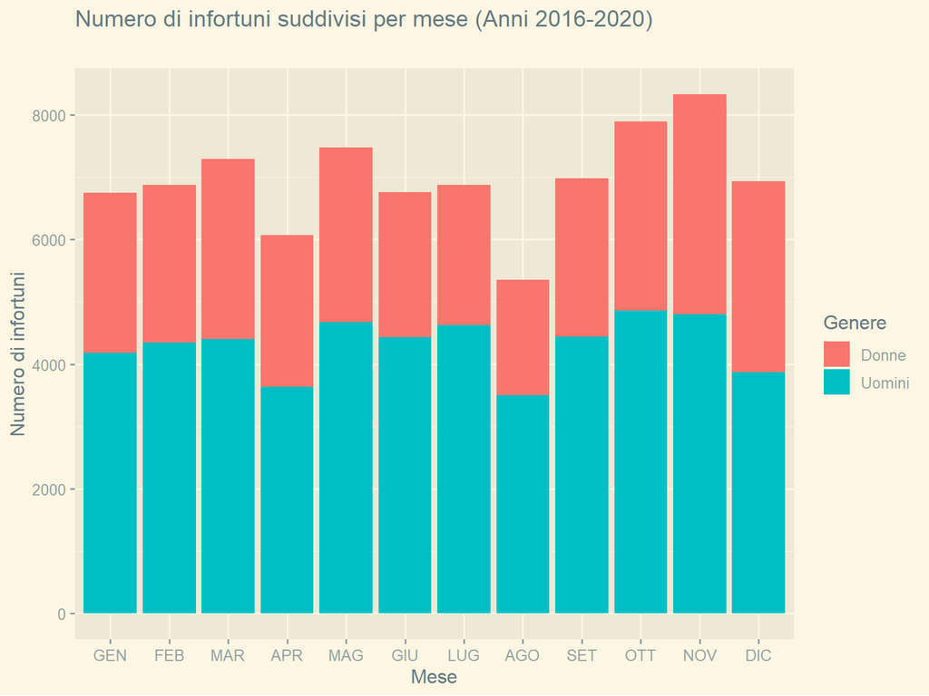

# Fonti

- Dati INAIL

> https://dati.inail.it/opendata/elements1/DatiConCadenzaMensileInfortuniFriuliVeneziaGiulia_
- Dati ISTAT

> http://dati.istat.it/
- Tabelle di decodifica

> https://www.inail.it/cs/internet/atti-e-documenti/moduli-e-modelli/prestazioni/denuncia-malattia-professionale/tabelle-di-decodifica.html